# Trabajo Final

Sarai Diaz

### Recursos sobre expresiones regulares:

1. [Rpubs](http://rpubs.com/ydmarinb/429756)
2. [Metriplica](https://www.metriplica.com/informes-y-estudios-de-analitica-digital/recursos-herramientas-de-analitica/expresiones-regulares/)

De las páginas presentadas, [Rpubs](http://rpubs.com/ydmarinb/429756) es la mejor opción para aprender sobre expresiones regulares debido a su ventaja en apariencia y contenido:

La apariencia resulta más atractiva y legible al estructurar su información en un menú de navegación lateral y la visualización de su detalle en el centro de la pantalla permitiendo así seleccionar cualquier tema sin necesidad de hacer scroll-down como ocurre en [Metriplica](https://www.metriplica.com/informes-y-estudios-de-analitica-digital/recursos-herramientas-de-analitica/expresiones-regulares/), aunque ofrece un simulador de expresiones regulares, funcionalidad que en [Rpubs](http://rpubs.com/ydmarinb/429756) no está presente, su usabilidad le hace perder esa ventaja.

El contenido en [Rpubs](http://rpubs.com/ydmarinb/429756) es más extenso y completo, un ejemplo de ello es la explicación que hacen ambas páginas sobre los metacaracteres especiales: en [Rpubs](http://rpubs.com/ydmarinb/429756) listan 5 tipos con su descripción mientras que en [Metriplica](https://www.metriplica.com/informes-y-estudios-de-analitica-digital/recursos-herramientas-de-analitica/expresiones-regulares/) sólo hacen un a breve mención de 3 sin descripción asociada.

### Recursos sobre markdown:

1. [Unavarra](http://www.unavarra.es/personal/tgoicoa/ESTADISTICA_RMarkdown_tomas/basicRmarkdown)
2. [Github Guides](https://guides.github.com/features/mastering-markdown/)

Tomando en cuenta la apariencia y contenido como critierio de evaluación, [Unavarra](http://www.unavarra.es/personal/tgoicoa/ESTADISTICA_RMarkdown_tomas/basicRmarkdown) resulta ser la mejor opción para aprender sobre expresiones markdown en R:

[Github Guides](https://guides.github.com/features/mastering-markdown/) ofrece una breve introdución sobre que es Markdown dando así un mayor contexto de la herramienta, pero enfocando su aplicación en Github, mientras que [Unavarra](http://www.unavarra.es/personal/tgoicoa/ESTADISTICA_RMarkdown_tomas/basicRmarkdown) indica de forma sencilla y concisa los pasos para su instalación e implementación en R.

Otra ventaja a destacar de [Unavarra](http://www.unavarra.es/personal/tgoicoa/ESTADISTICA_RMarkdown_tomas/basicRmarkdown) es la posibilidad de descargar los ejemplos que presenta, a diferencia de [Github Guides](https://guides.github.com/features/mastering-markdown/) que ni el resultado final de sus ejemplos se puede visualizar.

### Estudio descriptivo de los empleados de una empresa:

Carga de datos a través de una URL:

|  | id_empleado | area | antiguedad | edad | evaluacion | salario | baja | sexo | educacion |
| --- | --- | --- | --- | --- | --- | --- | --- | --- | --- |
| 1 | 21 | administrativa | 5 | 32 | 6.1 | 33,000 | 0 | H | Bachillerato |
| 2 | 25 | administrativa | 1 | 25 | 6.1 | 24,000 | 1 | H | Bachillerato |
| 3 | 26 | administrativa | 1 | 25 | 7.1 | 26,000 | 1 | M | Bachillerato |
| 4 | 27 | administrativa | 1 | 25 | 7.1 | 23,700 | 1 | M | Master |
| 5 | 30 | tecnica | 1 | 25 | 7.1 | 23,700 | 1 | H | Master |
| 6 | 31 | tecnica | 1 | 25 | 7.7 | 25,500 | 1 | M | Licenciatura |
| 7 | 32 | tecnica | 5 | 38 | 7.7 | 42,500 | 0 | M | Master |
| 8 | 32 | tecnica | 5 | 39 | 5.7 | 45,500 | 0 | M | Licenciatura |
| 9 | 33 | tecnica | 5 | 43 | 5.7 | 48,500 | 0 | H | Licenciatura |
| 10 | 34 | tecnica | 1 | 25 | 6.7 | 25,500 | 0 | H | Bachillerato |

[output cut: 787 more lines]

- Gráfico de distribución de empleados que estan de baja por antiguedad y sexo

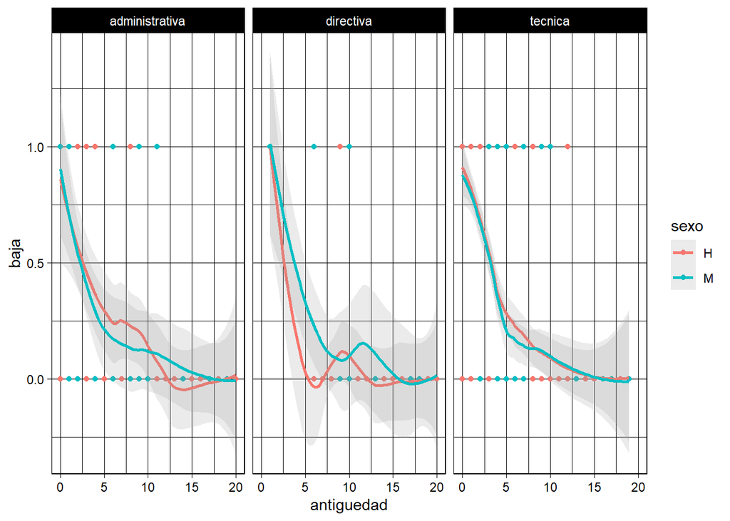

En general la empresa tiene alta rotación de empleados en sus 2 primeros años de antigüedad y el área donde se evidencia más este comportamiento es en la técnica, donde los hombres con más de 5 pero menos de 10 años de antiguedad, presentan una leve tendencia a irse en comparación con las mujeres.

### Gráfico de distribución de empleados por desempeño

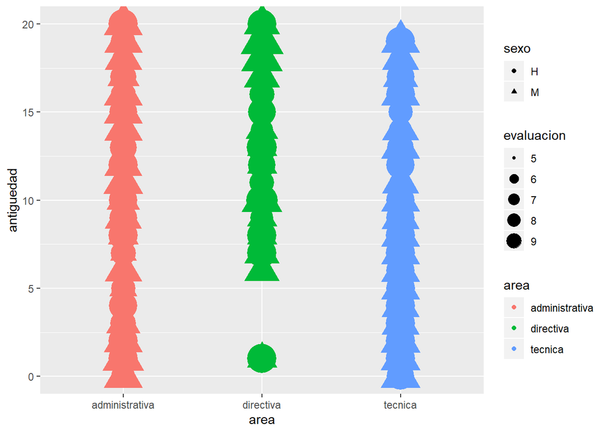

El área con menos participación pero con la mejor mínima puntación es la directiva, mientras que en el área ténica se observa más variedad y en la administrativa más constancia, pudiese ser debido al grado de rotación de cada área.

### Gráfico de correlación de variables de los empleados de una empresa

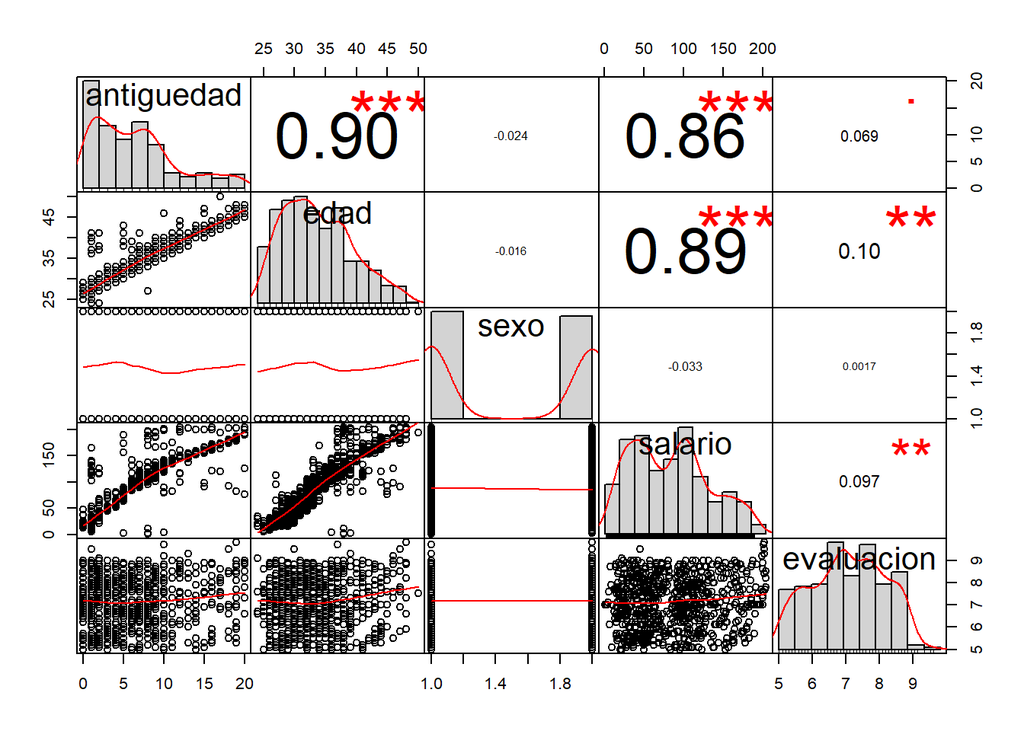